# Regularization

To minimize RSS, find model with highest R^2

## Regularization

- we wan to penalised model complexity

```r
#install.packages("glmnet")
library(glmnet)
library(tidyverse)
```

```r
wine <- read_csv("/Users/pp16/Desktop/NTU/UCL exchange/week 2 day 11/wine.csv")
```

```r
names(wine)[1] <- "f_acidity"
names(wine)[2] <- "v_acidity"
names(wine)[3] <- "citric_acid"
names(wine)[6] <- "free_so2"
names(wine)[7] <- "total_so2"
names(wine)[4] <- "res_sugar"

glimpse(wine)
```

```
Rows: 1,599
Columns: 12
$ f_acidity   <dbl> 7.4, 7.8, 7.8, 11.2, 7.4, 7.4, 7.9, 7.3, 7.8, 7.5, 6.7, 7.5, 5.6, 7.8,…
$ v_acidity   <dbl> 0.700, 0.880, 0.760, 0.280, 0.700, 0.660, 0.600, 0.650, 0.580, 0.500, …
$ citric_acid <dbl> 0.00, 0.00, 0.04, 0.56, 0.00, 0.00, 0.06, 0.00, 0.02, 0.36, 0.08, 0.36…
$ res_sugar   <dbl> 1.9, 2.6, 2.3, 1.9, 1.9, 1.8, 1.6, 1.2, 2.0, 6.1, 1.8, 6.1, 1.6, 1.6, …
$ chlorides   <dbl> 0.076, 0.098, 0.092, 0.075, 0.076, 0.075, 0.069, 0.065, 0.073, 0.071, …
$ free_so2    <dbl> 11, 25, 15, 17, 11, 13, 15, 15, 9, 17, 15, 17, 16, 9, 52, 51, 35, 16, …
$ total_so2   <dbl> 34, 67, 54, 60, 34, 40, 59, 21, 18, 102, 65, 102, 59, 29, 145, 148, 10…
$ density     <dbl> 0.9978, 0.9968, 0.9970, 0.9980, 0.9978, 0.9978, 0.9964, 0.9946, 0.9968…
$ pH          <dbl> 3.51, 3.20, 3.26, 3.16, 3.51, 3.51, 3.30, 3.39, 3.36, 3.35, 3.28, 3.35…
$ sulphates   <dbl> 0.56, 0.68, 0.65, 0.58, 0.56, 0.56, 0.46, 0.47, 0.57, 0.80, 0.54, 0.80…
$ alcohol     <dbl> 9.4, 9.8, 9.8, 9.8, 9.4, 9.4, 9.4, 10.0, 9.5, 10.5, 9.2, 10.5, 9.9, 9.…
$ quality     <dbl> 5, 5, 5, 6, 5, 5, 5, 7, 7, 5, 5, 5, 5, 5, 5, 5, 7, 5, 4, 6, 6, 5, 5, 5…
```

```r
str(wine)
```

```
spc_tbl_ [1,599 × 12] (S3: spec_tbl_df/tbl_df/tbl/data.frame)
 $ f_acidity  : num [1:1599] 7.4 7.8 7.8 11.2 7.4 7.4 7.9 7.3 7.8 7.5 ...
 $ v_acidity  : num [1:1599] 0.7 0.88 0.76 0.28 0.7 0.66 0.6 0.65 0.58 0.5 ...
 $ citric_acid: num [1:1599] 0 0 0.04 0.56 0 0 0.06 0 0.02 0.36 ...
 $ res_sugar  : num [1:1599] 1.9 2.6 2.3 1.9 1.9 1.8 1.6 1.2 2 6.1 ...
 $ chlorides  : num [1:1599] 0.076 0.098 0.092 0.075 0.076 0.075 0.069 0.065 0.073 0.071 ...
 $ free_so2   : num [1:1599] 11 25 15 17 11 13 15 15 9 17 ...
 $ total_so2  : num [1:1599] 34 67 54 60 34 40 59 21 18 102 ...
 $ density    : num [1:1599] 0.998 0.997 0.997 0.998 0.998 ...
 $ pH         : num [1:1599] 3.51 3.2 3.26 3.16 3.51 3.51 3.3 3.39 3.36 3.35 ...
 $ sulphates  : num [1:1599] 0.56 0.68 0.65 0.58 0.56 0.56 0.46 0.47 0.57 0.8 ...
 $ alcohol    : num [1:1599] 9.4 9.8 9.8 9.8 9.4 9.4 9.4 10 9.5 10.5 ...
 $ quality    : num [1:1599] 5 5 5 6 5 5 5 7 7 5 ...
 - attr(*, "spec")=
  .. cols(
  ..   `fixed acidity` = col_double(),
  ..   `volatile acidity` = col_double(),
  ..   `citric acid` = col_double(),
  ..   `residual sugar` = col_double(),
  ..   chlorides = col_double(),
  ..   `free sulfur dioxide` = col_double(),
  ..   `total sulfur dioxide` = col_double(),
  ..   density = col_double(),
  ..   pH = col_double(),
  ..   sulphates = col_double(),
  ..   alcohol = col_double(),
  ..   quality = col_double()
  .. )
 - attr(*, "problems")=<externalptr>
```

- when landa is small, we are applying little weight on penalty, may result in overfitting
- when landa is large, we focus almost entirely on penalty, penalty is based on size of coefficicient, the coefficients are shrunk, coefficients are driven towards zero, making it more simple models

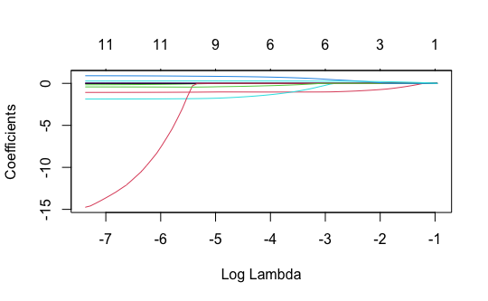

```r
wine_x <- select(wine, -quality)
wine_y <- wine$quality

fit_lasso <- glmnet(x=data.matrix(wine_x),
                    y=wine_y,
                    alpha = 1)
plot(fit_lasso, xvar="lambda")
```

- As log lambda increases, the penalty on the coefficients increases, forcing more coeffecients to shrunk to zero
- The number of coefficients decreases from 11 to 1

See how, as (the logarithm of) landa increases, coefficient values are “shrunk” towards zero. The numbers along the top of the plot indicate how many non-zero coefficients there are in the model, reducing from the full set of 11 available coefficients at the smallest values of landa to only a single coefficient at the largest values of landa.

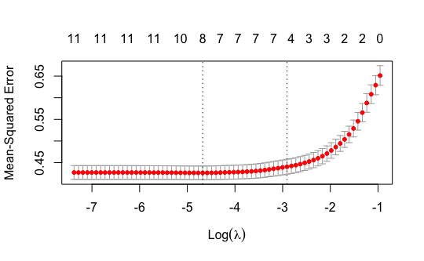

```r
set.seed(1)
results_lasso <- cv.glmnet(x=data.matrix(wine_x),
                           y=wine_y,
                           alpha=1,
                           nfolds=10)
plot(results_lasso)
```

- at 8 coefficients seems the lowest mean square error
- but we choose the simplest model which is the one at around 4 coefficients that lies in the same range

```r
opt_fit_lasso <- glmnet(x=data.matrix(wine_x),
                        y=wine_y,
                        alpha = 1,
                        lambda = results_lasso$lambda.1se)
coef(opt_fit_lasso)
```

```
12 x 1 sparse Matrix of class "dgCMatrix"
                       s0
(Intercept)  3.1816030227
f_acidity    .
v_acidity   -1.0152494020
citric_acid  .
res_sugar    .
chlorides   -0.0885194274
free_so2     .
total_so2   -0.0008119963
density      .
pH           .
sulphates    0.4577701017
alcohol      0.2623512120
```

```r
library(cvTools)
cv_opt_lasso <- cvFit(opt_fit_lasso,
                      data = data.matrix(wine_x),
                      y = wine_y,
                      k=5,
                      R=30 )
cv_opt_lasso$cv
```

```
       CV
0.6601587
```

## Ridge regression

- error is not absolute, but square of sum of error (sum of positive)
- squaring penalise smaller values
- even greater penalty

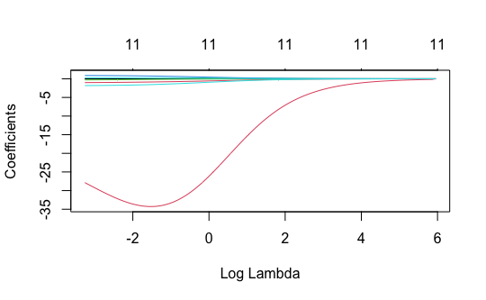

```r
fit_ridge <- glmnet(x=data.matrix(wine_x),
                    y=wine_y,
                    alpha = 0)
plot(fit_ridge, xvar="lambda")
```

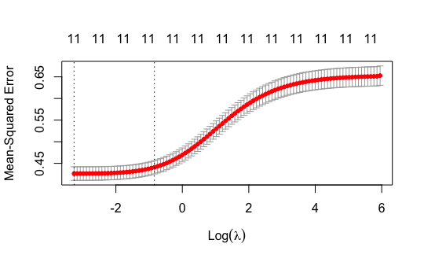

```r
set.seed(1)
results_ridge <- cv.glmnet(x=data.matrix(wine_x),
                           y=wine_y,
                           alpha=0,
                           nfolds=10)
plot(results_ridge)
```

```r
opt_fit_ridge <- glmnet(x=data.matrix(wine_x),
                        y=wine_y,
                        alpha = 0,
                        lambda = results_ridge$lambda.1se)
coef(opt_fit_ridge)
```

```
12 x 1 sparse Matrix of class "dgCMatrix"
                       s0
(Intercept)  36.599813860
f_acidity     0.022635336
v_acidity    -0.745434627
citric_acid   0.180134683
res_sugar     0.013385197
chlorides    -1.309088673
free_so2      0.001041995
total_so2    -0.002111242
density     -32.620790439
pH           -0.120931259
sulphates     0.626046711
alcohol       0.178227896
```

```r
cv_opt_ridge <- cvFit(opt_fit_ridge,
                      data = data.matrix(wine_x),
                      y = wine_y,
                      k=5,
                      R=30 )
cv_opt_ridge$cv
```

```
       CV
0.6597769
```

## Covariate standardisation

It is a common pitfall of students new to statistics that the magnitude of coefficients in linear regression indicates the importance of their corresponding covariate.

For example, consider the model:

𝑦=0+1×𝑥1+10×𝑥2

One might assume that 𝑥2 is ten times as important as 𝑥1 – changing 𝑥2 by one unit has ten times the impact on 𝑦 as changing 𝑥1 by one unit.

The missing piece from that argument is that the scales of 𝑥1 and 𝑥2 may vary. If 𝑥1 varies between 0 and 100 and 𝑥2 varies between 0 and 0.01, it is likely that 𝑥1 will have a considerably greater impact on 𝑦 (through 1×𝑥1) than 𝑥2 will have on 𝑦 (through 10×𝑥2).

Ridge regression and the lasso combine coefficient estimates in the penalty term without any scaling, reducing the size of coefficients for covariates determined to be less important. It is therefore imperative that the coefficients are on the same scale, ensured by *standardising* the covariates: 𝑥′= (𝑥−𝑚𝑒𝑎𝑛(𝑥))/𝑠𝑑(𝑥)

If we were to implement ridge regression or the lasso manually then we would need to carry out that standardisation. As it is, the implementation in R above standarises the covariates, performs the model fit, then reverses the standardisation process without requiring us to do anything ourselves.